# Tree Manipulation

Guangchuang Yu School of Basic Medical Sciences, Southern Medical University

2018-11-29

# Internal node number

Some of the functions in `ggtree` work with clade and accept a parameter of internal node number. To get the internal node number, user can use `geom_text2` to display it:

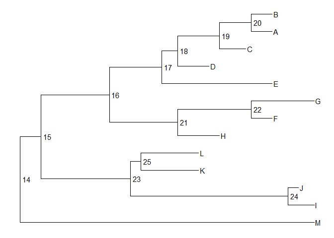

```r
nwk <- system.file("extdata", "sample.nwk", package="treeio")
tree <- read.tree(nwk)
ggtree(tree) + geom_text2(aes(subset=!isTip, label=node), hjust=-.3) + geom_tiplab()
```

Another way to get the internal node number is using `MRCA()` function by providing a vector of taxa names. The function will return node number of input taxa’s most recent commond ancestor (MRCA). It works with tree and graphic object.

```r
MRCA(tree, tip=c('A', 'E'))
```

```
## [1] 17
```

```r
MRCA(tree, tip=c('H', 'G'))
```

```
## [1] 21
```

```r
p <- ggtree(tree)
MRCA(p, tip=c('A', 'E'))
```

```
## [1] 17
```

# View Clade

`ggtree` provides a function `viewClade` to visualize a clade of a phylogenetic tree.

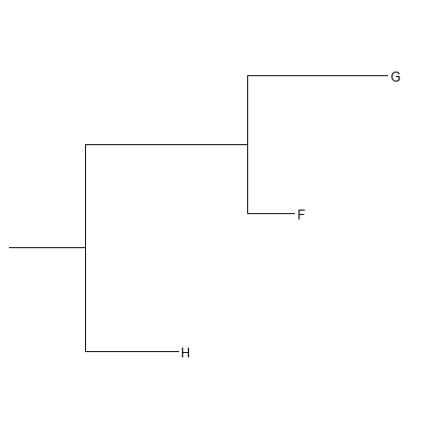

```r
viewClade(p+geom_tiplab(), node=21)
```

# Group Clades

The `ggtree` package defined several functions to manipulate tree view. *`groupClade`* and *`groupOTU`* methods were designed for clustering clades or related OTUs. *`groupClade`* accepts an internal node or a vector of internal nodes to cluster clade/clades.

Both *`groupClade`* and *`groupOTU`* work fine with tree and graphic object.

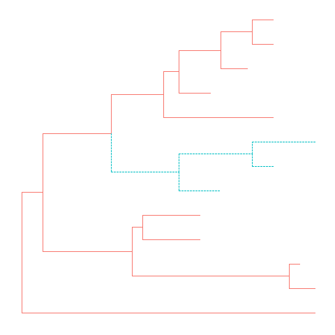

```r
tree <- groupClade(tree, .node=21)
ggtree(tree, aes(color=group, linetype=group))
```

The following command will produce the same figure.

```r
ggtree(read.tree(nwk)) %>% groupClade(.node=21) + aes(color=group, linetype=group)
```

With `groupClade` and `groupOTU`, it’s easy to highlight selected taxa and easy to select taxa to display related features.

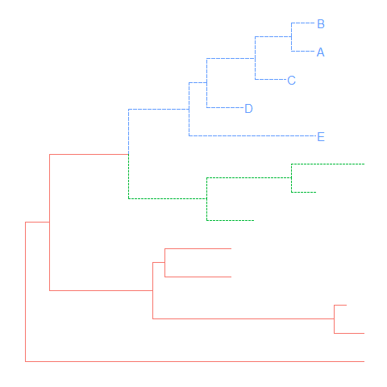

```r
tree <- groupClade(tree, .node=c(21, 17))
ggtree(tree, aes(color=group, linetype=group)) + geom_tiplab(aes(subset=(group==2)))
```

# Group OTUs

*`groupOTU`* accepts a vector of OTUs (taxa name) or a list of OTUs. *`groupOTU`* will trace back from OTUs to their most recent common ancestor and cluster them together. Related OTUs are not necessarily within a clade, they can be monophyletic (clade), polyphyletic or paraphyletic.

```r
tree <- groupOTU(tree, .node=c("D", "E", "F", "G"))
```

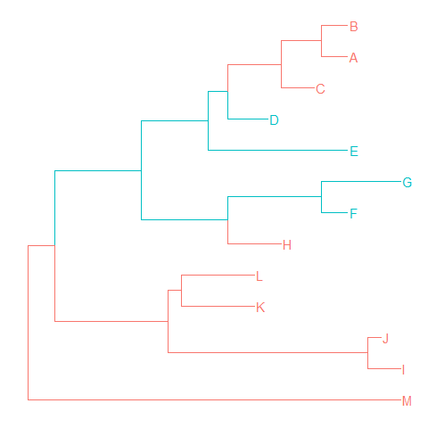

```r
ggtree(tree, aes(color=group)) + geom_tiplab()
```

*`groupOTU`* can also input a list of tip groups.

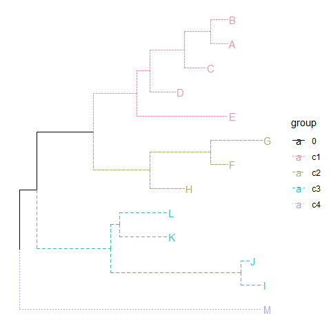

```r
cls <- list(c1=c("A", "B", "C", "D", "E"),
            c2=c("F", "G", "H"),
            c3=c("L", "K", "I", "J"),
            c4="M")

tree <- groupOTU(tree, cls)
library("colorspace")
ggtree(tree, aes(color=group, linetype=group)) + geom_tiplab() +
     scale_color_manual(values=c("black", rainbow_hcl(4))) + theme(legend.position="right")
```

*`groupOTU`* also works with graphic object.

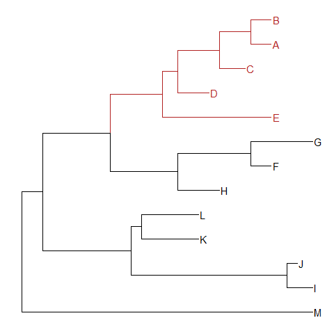

```r
p <- ggtree(tree)
groupOTU(p, LETTERS[1:5]) + aes(color=group) + geom_tiplab() + scale_color_manual(values=c("black", "firebrick"))
```

The following example use `groupOTU` to display taxa classification.

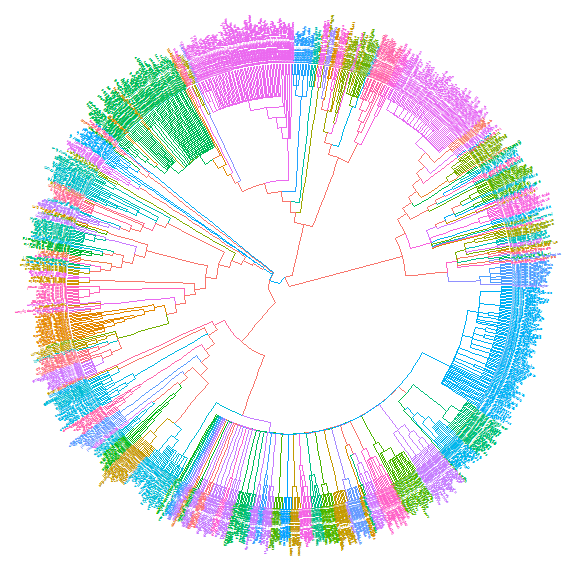

```r
library("ape")
data(chiroptera)
groupInfo <- split(chiroptera$tip.label, gsub("_\\w+", "", chiroptera$tip.label))
chiroptera <- groupOTU(chiroptera, groupInfo)
ggtree(chiroptera, aes(color=group), layout='circular') + geom_tiplab(size=1, aes(angle=angle))
```

# Collapse clade

With *`collapse`* function, user can collapse a selected clade.

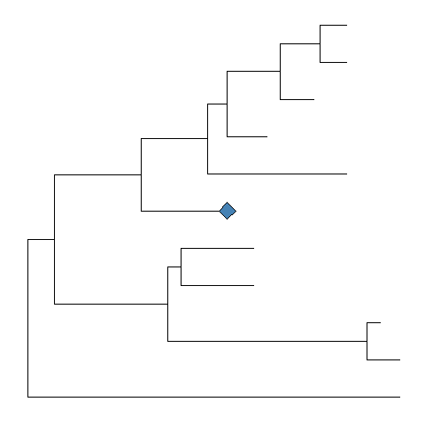

```r
cp <- collapse(p, node=21)
cp + geom_point2(aes(subset=(node == 21)), size=5, shape=23, fill="steelblue")
```

# Expand collapsed clade

The collapsed clade can be expanded via *`expand`* function.

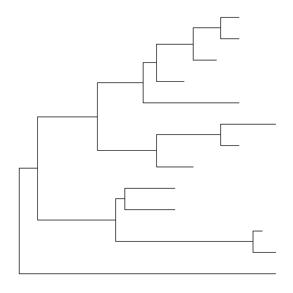

```r
cp %>% expand(node=21)
```

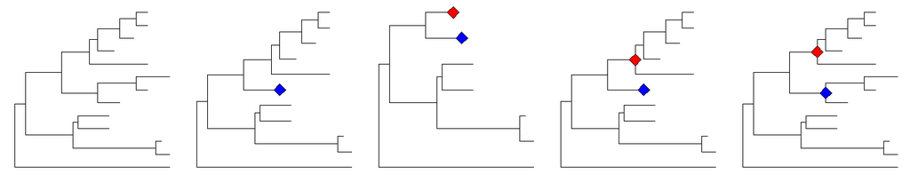

```r
p1 <- ggtree(tree)
p2 <- collapse(p1, 21) + geom_point2(aes(subset=(node==21)), size=5, shape=23, fill="blue")
p3 <- collapse(p2, 17) + geom_point2(aes(subset=(node==17)), size=5, shape=23, fill="red")
p4 <- expand(p3, 17)
p5 <- expand(p4, 21)

library(cowplot)
plot_grid(p1, p2, p3, p4, p5, ncol=5)
```

# Scale clade

Collpase selected clades can save some space, another approach is to zoom out clade to a small scale.

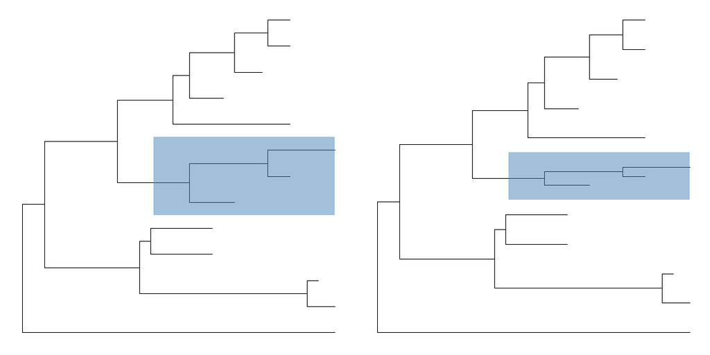

```r
plot_grid(ggtree(tree) + geom_hilight(21, "steelblue"),
          ggtree(tree) %>% scaleClade(21, scale=0.3) + geom_hilight(21, "steelblue"),
          ncol=2)
```

Of course, *`scaleClade`* can accept `scale` larger than 1 and zoom in the selected portion.

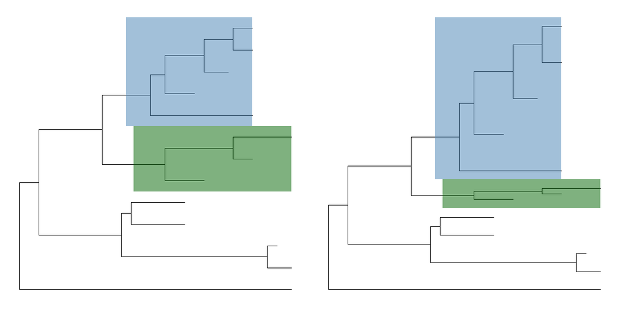

```r
plot_grid(ggtree(tree) + geom_hilight(17, fill="steelblue") +
                 geom_hilight(21, fill="darkgreen"),
          ggtree(tree) %>% scaleClade(17, scale=2) %>% scaleClade(21, scale=0.3) +
                 geom_hilight(17, "steelblue") + geom_hilight(21, fill="darkgreen"),
          ncol=2)
```

# Rotate clade

A selected clade can be rotated by 180 degree using **`rotate`** function.

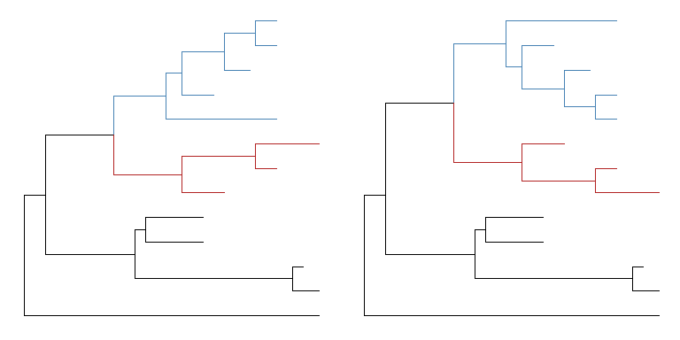

```r
tree <- groupClade(tree, c(21, 17))
p <- ggtree(tree, aes(color=group)) + scale_color_manual(values=c("black", "firebrick", "steelblue"))
p2 <- rotate(p, 21) %>% rotate(17)
plot_grid(p, p2, ncol=2)
```

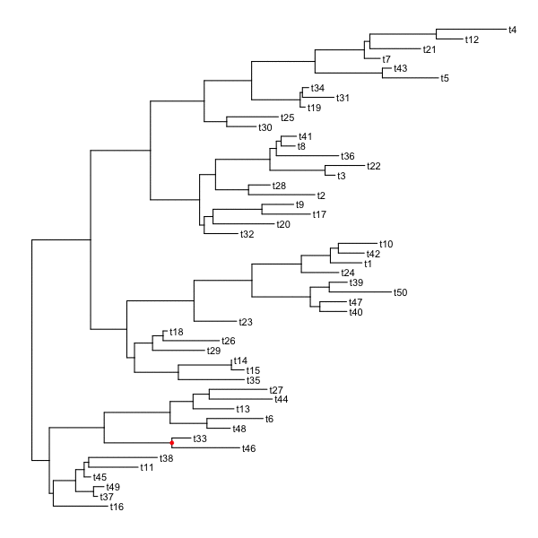

```r
set.seed(2016-05-29)
p <- ggtree(tree <- rtree(50)) + geom_tiplab()
for (n in reorder(tree, 'postorder')$edge[,1] %>% unique) {
    p <- rotate(p, n)
    print(p + geom_point2(aes(subset=(node == n)), color='red'))
}
```

# Flip clade

The positions of two selected clades (should share a same parent) can be flip over using **`flip`** function.

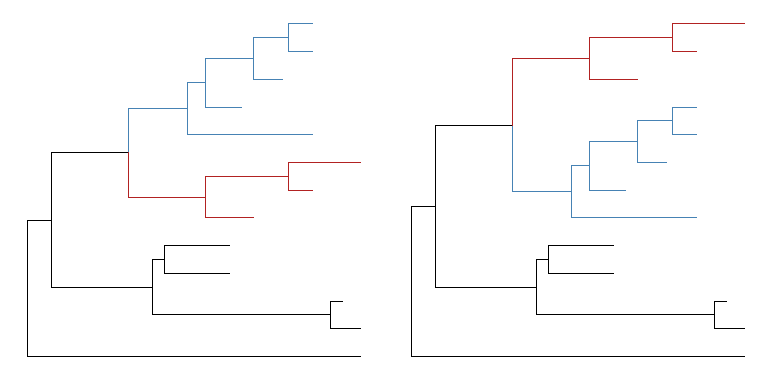

```r
plot_grid(p, flip(p, 17, 21), ncol=2)
```

# Open tree

`ggtree` supports `fan` layout and can also transform the `circular` layout tree to a `fan` tree by specifying an open `angle` to `open_tree` function.

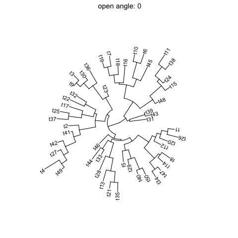

```r
set.seed(123)
tr <- rtree(50)

p <- ggtree(tr, layout='circular') + geom_tiplab2()

for (angle in seq(0, 270, 10)) {
    print(open_tree(p, angle=angle) + ggtitle(paste("open angle:", angle)))
}
```

# Rotate tree

Rotating a `circular` tree is supported by `rotate_tree` function.

```r
for (angle in seq(0, 270, 10)) {
    print(rotate_tree(p, angle) + ggtitle(paste("rotate angle:", angle)))
}
```

[figure not shown]

# Interactive tree manipulation

Interactive tree manipulation is also possible, please refer to https://guangchuangyu.github.io/2016/06/identify-method-for-ggtree.